# WR_v4_PCAs

## PCs 2 vs 3

```r
evec$time_window=factor(evec$time_window,levels=c("NWRpre","NWRpost","SWRpre", "SWRpost"))
```

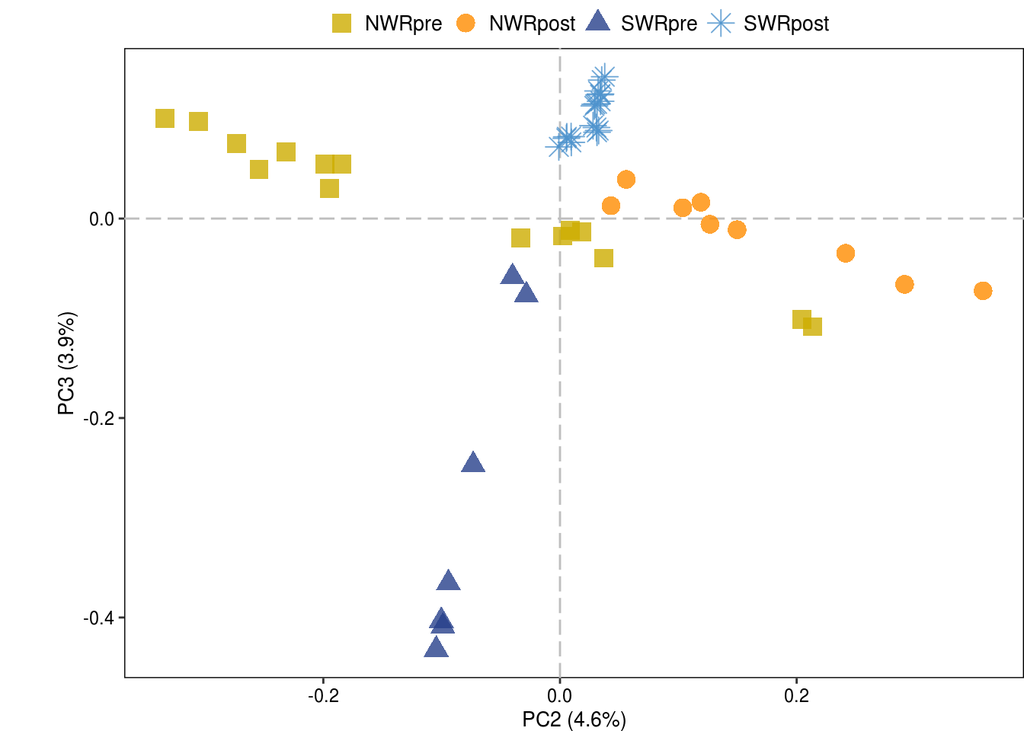

```r
## PC2 vs PC3
B = ggplot(evec, aes(x=PC2, y=PC3)) +

  # draw intercept lines
  geom_vline(xintercept=0, colour="gray", linetype = "longdash")+
  geom_hline(yintercept=0, colour="gray", linetype = "longdash")+

  # plot data points (2 legend alternatives)
  geom_point(aes(colour = time_window, shape = time_window), alpha=.8, size=4) +

  # assign colors and shapes
  scale_colour_manual(values=c("gold3", "darkorange", "royalblue4", "steelblue3")) +
  scale_shape_manual(values=c(15, 16, 17, 8)) +

  # labels, titles, background, etc.
  xlab(paste0("PC2 (", round(eval[2]*100, 2), "%)"))+
  ylab(paste0("PC3 (", round(eval[3]*100, 2), "%)"))+

  theme(panel.background = element_rect(fill='white', colour='black'), axis.text.x = element_text(colour='black'), axis.text.y = element_text(colour='black'),
        strip.background = element_rect(size=.2, colour="black", fill ="#FFA5004D"), panel.grid.major = element_blank(), panel.grid.minor = element_blank(),
        legend.title=element_text(size=0), legend.key=element_rect(fill="white", colour="white"), axis.title=element_text(size=10), legend.text=element_text(size=10), legend.key.size=unit(.8, "cm"),
        legend.position = "top", legend.margin=margin(0,0,0,0), legend.box.margin=margin(0,-10,-10,-10), plot.margin=unit(c(0,0,0,1), "cm"))

B
```

## PCA’s per subspecies

### NWR

Open the covariance matrices of NWR or SWR and do the eigen decomposition into vectors and values

```r
# prepare covariance matrix
NWR <-"NWR.24I.above13Mb_NoSexChr_NonMaskedRegions_GL2_unrelated.tv.cov"
mNWR <- as.matrix(read.table(NWR))

# run the eigen decomposition
eNWR <- eigen(mNWR)

# calculate the eigenvalues
evalNWR = eNWR$values/sum(eNWR$values)
```

Prepare the metadata

```r
mdNWR = md_unrel[md_unrel$subspecies == "cottoni", ]
```

Select PCs to plot and bind them to metadata

```r
# PC1 and PC2
pcsNWR <- as.data.frame(eNWR$vectors[,1:3])
colnames(pcsNWR) = c("PC1", "PC2", "PC3")

# Extract relevant columns from metadata for plotting
mini_mdNWR = as.data.frame(mdNWR %>% select(sample_name, lab_ID, time_window, country))

evecNWR <- cbind(mini_mdNWR, pcsNWR)
head(evecNWR)
```

```
##   sample_name     lab_ID time_window country        PC1          PC2
## 3    CD1912.1 mwr_TG0451      NWRpre     DRC -0.2815388 -0.017491870
## 4    CD1912.2 mwr_TG0452      NWRpre     DRC -0.2249683 -0.053493357
## 5    CD1911.1 mwr_TG0453      NWRpre     DRC -0.3175902  0.018674592
## 6    CD1913.1 mwr_TG0454      NWRpre     DRC -0.3548159  0.017360268
## 7    CD1912.3 mwr_TG0455      NWRpre     DRC -0.1946164 -0.034446901
## 8    CD1911.2 mwr_TG0456      NWRpre     DRC -0.2515404 -0.008557451
##            PC3
## 3 -0.063199631
## 4 -0.014503741
## 5  0.340176318
## 6  0.247431275
## 7 -0.005422313
## 8  0.007268127
```

Make a composite column for the legend

```r
evecNWR$window_country <- paste(evecNWR$time_window, evecNWR$country, sep = " ")
head(evecNWR)
```

```
##   sample_name     lab_ID time_window country        PC1          PC2
## 3    CD1912.1 mwr_TG0451      NWRpre     DRC -0.2815388 -0.017491870
## 4    CD1912.2 mwr_TG0452      NWRpre     DRC -0.2249683 -0.053493357
## 5    CD1911.1 mwr_TG0453      NWRpre     DRC -0.3175902  0.018674592
## 6    CD1913.1 mwr_TG0454      NWRpre     DRC -0.3548159  0.017360268
## 7    CD1912.3 mwr_TG0455      NWRpre     DRC -0.1946164 -0.034446901
## 8    CD1911.2 mwr_TG0456      NWRpre     DRC -0.2515404 -0.008557451
##            PC3 window_country
## 3 -0.063199631     NWRpre DRC
## 4 -0.014503741     NWRpre DRC
## 5  0.340176318     NWRpre DRC
## 6  0.247431275     NWRpre DRC
## 7 -0.005422313     NWRpre DRC
## 8  0.007268127     NWRpre DRC
```

Set the order of the levels in the legend

```r
evecNWR$window_country=factor(evecNWR$window_country, levels=c("NWRpre DRC", "NWRpre South Sudan", "NWRpre Uganda", "NWRpost Sudan", "NWRpost South Sudan", "NWRpost Uganda"))
```

Visualize PCs with legend per subspecies, time window and country of origin (new column in dataframe)

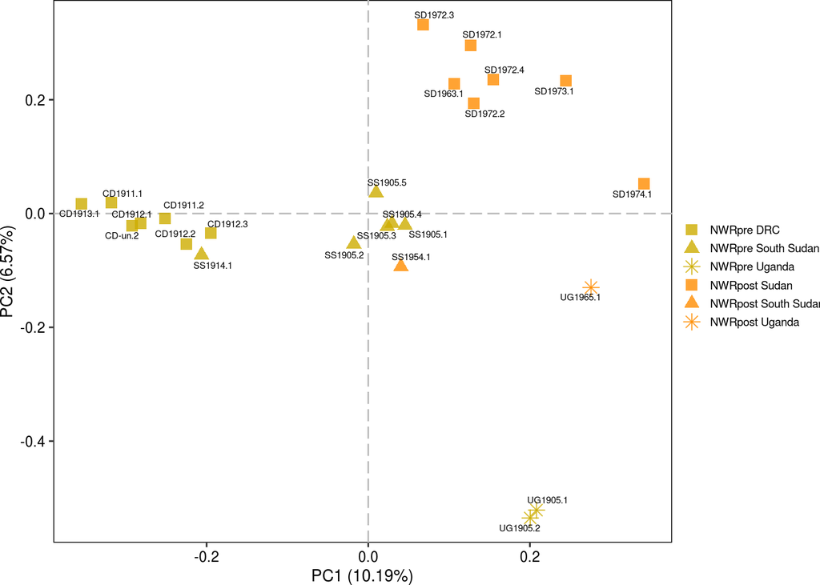

```r
## PC1 vs PC2
nwr = ggplot(evecNWR, aes(x=PC1, y=PC2)) +

  # draw intercept lines
  geom_vline(xintercept=0, colour="gray", linetype = "longdash")+
  geom_hline(yintercept=0, colour="gray", linetype = "longdash")+

  # plot data points (2 legend alternatives)
  geom_point(aes(colour = window_country, shape = window_country), alpha=.8, size=3) +

  # assign colors and shapes
  scale_colour_manual(values=c("gold3", "gold3", "gold3", "darkorange", "darkorange", "darkorange")) +
  scale_shape_manual(values=c(15, 17, 8, 15, 17, 8)) +


  # labels, titles, background, etc.
  xlab(paste0("PC1 (", round(evalNWR[1]*100, 2), "%)"))+
  ylab(paste0("PC2 (", round(evalNWR[2]*100, 2), "%)"))+

  theme(panel.background = element_rect(fill='white', colour='black'), axis.text.x = element_text(colour='black'), axis.text.y = element_text(colour='black'),
        strip.background = element_rect(size=.2, colour="black", fill ="#FFA5004D"), panel.grid.major = element_blank(), panel.grid.minor = element_blank(),
        legend.title=element_blank(), legend.key=element_rect(fill="white", colour="white"), axis.title=element_text(size=10), legend.text=element_text(size=7), legend.key.size=unit(.4, "cm"),
        legend.box.margin=margin(-10,-10,-10,-10), plot.margin=margin(0,2,0,0)) +

  #guides(colour = guide_legend(order = 1), shape = guide_legend(order = 2))
  geom_text_repel(data=evecNWR, aes(label=sample_name), segment.size=.15, size=2)

nwr
```

### SWR

Open the covariance matrices of NWR or SWR and do the eigen decomposition into vectors and values

```r
# prepare covariance matrix
SWR <-"SWR.25I.above13Mb_NoSexChr_NonMaskedRegions_GL2_unrelated.tv.cov"
mSWR <- as.matrix(read.table(SWR))

# run the eigen decomposition
eSWR <- eigen(mSWR)

# calculate the eigenvalues
evalSWR = eSWR$values/sum(eSWR$values)
```

Prepare the metadata

```r
mdSWR = md_unrel[md_unrel$subspecies == "simum", ]
```

Select PCs to plot and bind them to metadata

```r
# PC1 and PC2
pcsSWR <- as.data.frame(eSWR$vectors[,1:3])
colnames(pcsSWR) = c("PC1", "PC2", "PC3")

# Extract relevant columns from metadata for plotting
mini_mdSWR = as.data.frame(mdSWR %>% select(sample_name, lab_ID, time_window, country))

evecSWR <- cbind(mini_mdSWR, pcsSWR)
head(evecSWR)
```

```
##    sample_name     lab_ID time_window      country         PC1        PC2
## 1     ZA1869.1 mwr_TG0449      SWRpre South Africa -0.04507757 -0.4406562
## 15    ZA1845.1  mwr_TGF01      SWRpre South Africa -0.22692681 -0.5335439
## 17     ZA-un.1  mwr_TGF03      SWRpre South Africa -0.43763524  0.2749867
## 18    ZA1845.2  mwr_TGF04      SWRpre South Africa -0.03167600 -0.3706399
## 19    NA1856.1  mwr_TGF05      SWRpre      Namibia -0.36839036 -0.2287903
## 20    NA1845.1  mwr_TGF06      SWRpre      Namibia -0.43262958  0.2116716
##           PC3
## 1  -0.3993141
## 15  0.1507795
## 17 -0.4100386
## 18 -0.1883351
## 19  0.6289762
## 20  0.2414593
```

Make a composite column for the legend

```r
evecSWR$window_country <- paste(evecSWR$time_window, evecSWR$country, sep = " ")
head(evecSWR)
```

```
##    sample_name     lab_ID time_window      country         PC1        PC2
## 1     ZA1869.1 mwr_TG0449      SWRpre South Africa -0.04507757 -0.4406562
## 15    ZA1845.1  mwr_TGF01      SWRpre South Africa -0.22692681 -0.5335439
## 17     ZA-un.1  mwr_TGF03      SWRpre South Africa -0.43763524  0.2749867
## 18    ZA1845.2  mwr_TGF04      SWRpre South Africa -0.03167600 -0.3706399
## 19    NA1856.1  mwr_TGF05      SWRpre      Namibia -0.36839036 -0.2287903
## 20    NA1845.1  mwr_TGF06      SWRpre      Namibia -0.43262958  0.2116716
##           PC3      window_country
## 1  -0.3993141 SWRpre South Africa
## 15  0.1507795 SWRpre South Africa
## 17 -0.4100386 SWRpre South Africa
## 18 -0.1883351 SWRpre South Africa
## 19  0.6289762      SWRpre Namibia
## 20  0.2414593      SWRpre Namibia
```

Set the correct order of the levels in the legend

```r
evecSWR$window_country=factor(evecSWR$window_country, levels=c("SWRpre South Africa", "SWRpre Namibia", "SWRpost unknown", "SWRpost South Africa", "SWRpost captive"))
```

Visualize the PCs

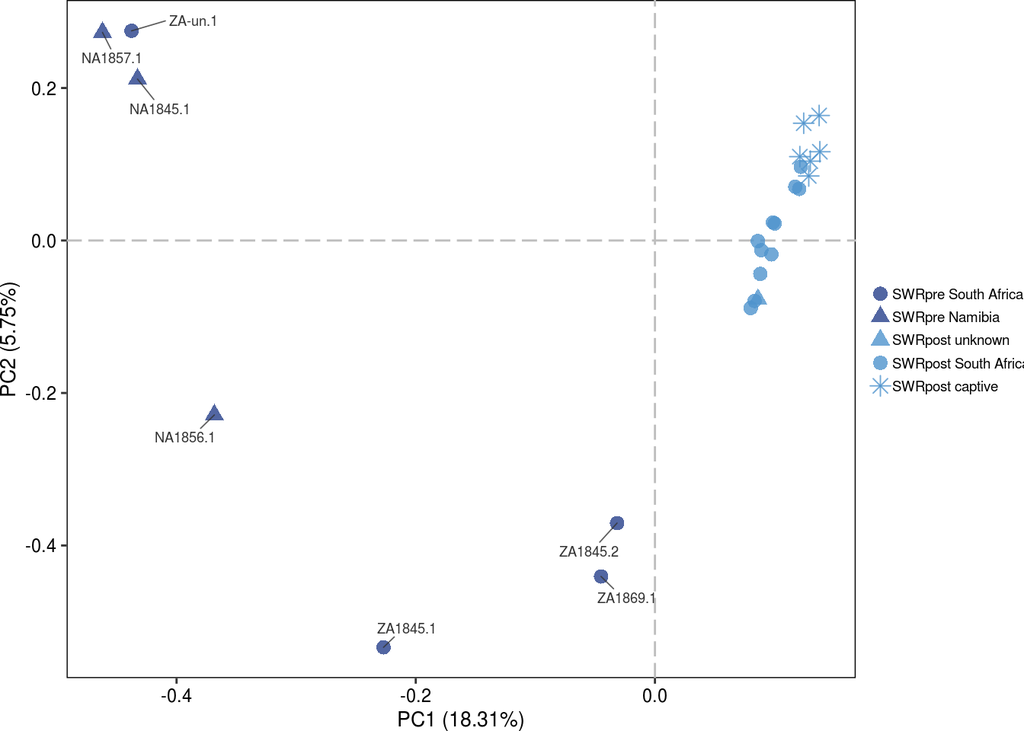

```r
## PC1 vs PC2
swr = ggplot(evecSWR, aes(x=PC1, y=PC2)) +

  # draw intercept lines
  geom_vline(xintercept=0, colour="gray", linetype = "longdash")+
  geom_hline(yintercept=0, colour="gray", linetype = "longdash")+

  # plot data points (2 legend alternatives)
  geom_point(aes(colour = window_country, shape = window_country), alpha=.8, size=3) +

  # assign colors and shapes
  scale_colour_manual(values=c("royalblue4", "royalblue4", "steelblue3", "steelblue3", "steelblue3")) +
  scale_shape_manual(values=c(16, 17, 17, 16, 8)) +

  # labels, titles, background, etc.
  xlab(paste0("PC1 (", round(evalSWR[1]*100, 2), "%)"))+
  ylab(paste0("PC2 (", round(evalSWR[2]*100, 2), "%)"))+

  theme(panel.background = element_rect(fill='white', colour='black'), axis.text.x = element_text(colour='black'), axis.text.y = element_text(colour='black'),
        strip.background = element_rect(size=.2, colour="black", fill ="#FFA5004D"), panel.grid.major = element_blank(), panel.grid.minor = element_blank(),
        legend.title=element_text(size=0), legend.key=element_rect(fill="white", colour="white"), axis.title=element_text(size=10), legend.text=element_text(size=7), legend.key.size=unit(.4, "cm"),
        legend.box.margin=margin(-10,-10,-10,-10), plot.margin=margin(0,2,0,0)) +

  geom_text_repel(data=subset(evecSWR, time_window=="SWRpre"), aes(label=sample_name), segment.size=.3, segment.alpha=.8, size=2.4, force=20, box.padding=0.5, colour="gray20")


swr
```

### Arrange the composite figure with the PCAs of interest

Fist get the legend of the first plot with both subpescies

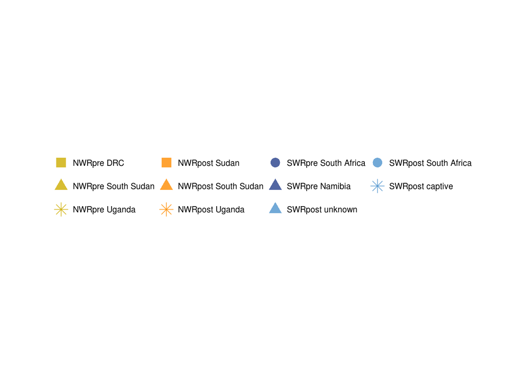

```r
# Extract the legend. Returns a gtable
leg <- get_legend(A)

# Convert to a ggplot and print
as_ggplot(leg)
```

Now arrange the per-subspecies plots in a column

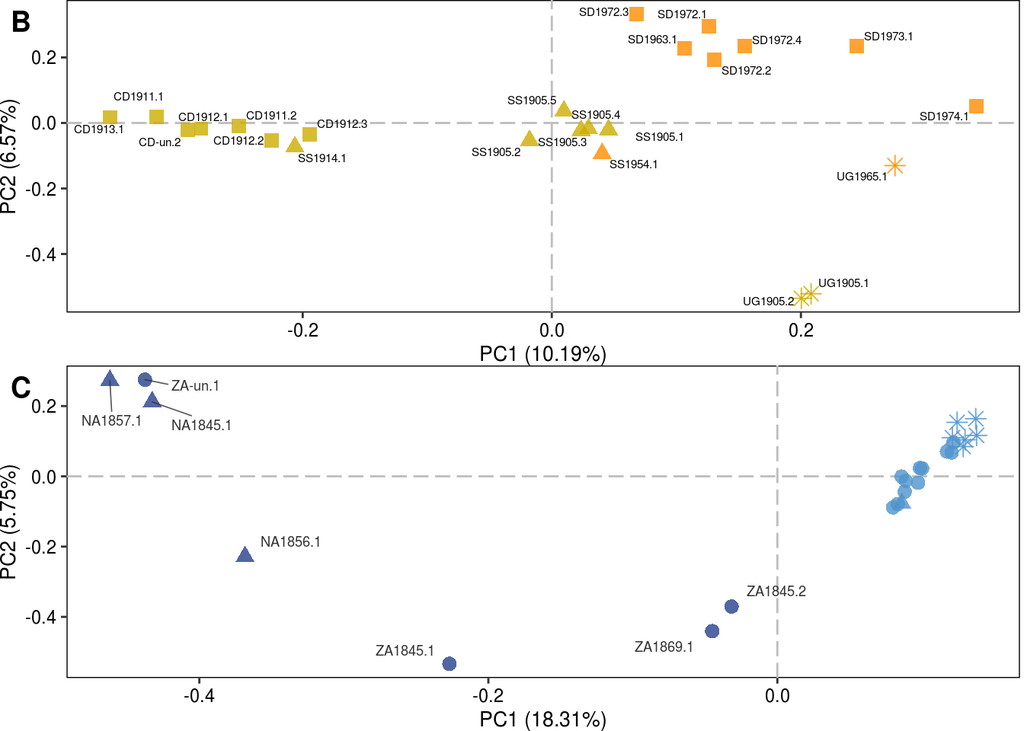

```r
subsp = ggarrange(nwr + guides(colour=F, shape=F), swr + guides(colour=F, shape=F), nrow = 2, ncol = 1, labels=c("B", "C"))
subsp
```

Now arrange the first plot for both subspecies plus the column of per-subspecies plots

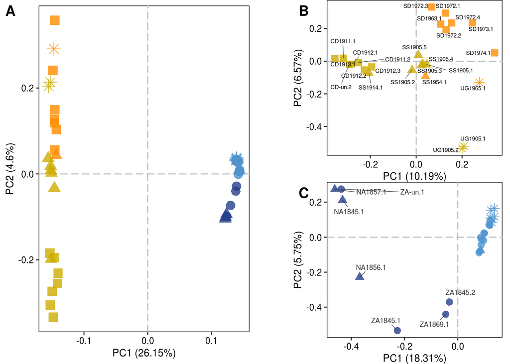

```r
PCAps = ggarrange(A + guides(colour=F, shape=F), subsp, nrow=1, ncol=2, labels=c("A", NULL), align = c("v"))
PCAps
```

Now add the common legend for all 3 plots

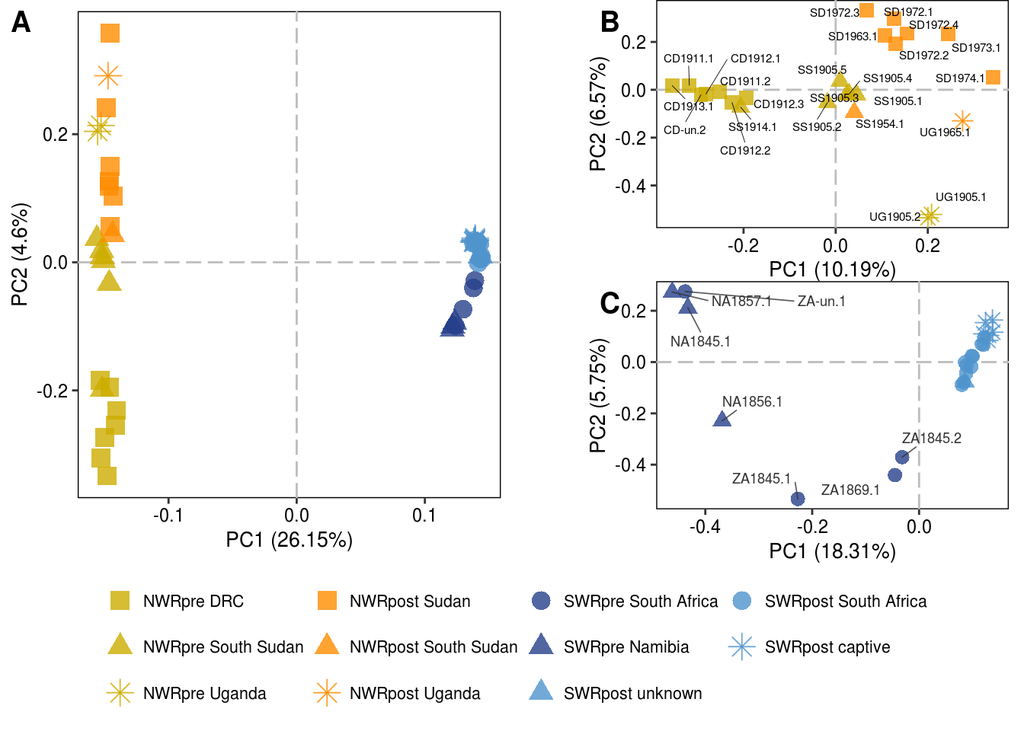

```r
fig = plot_grid(PCAps, leg, ncol = 1, rel_heights = c(1, .3))
fig
```

```r
# pdf('WR_v5_Fig2_PCAs.pdf', height=6, width=8, useDingbats = F)
# fig
# dev.off()
```